# Intro to SQL

Katie Jobson & William Mitchell

2023-07-27

# 1 Introduction

[video not shown]

## 1.1 What is SQL?

[figure not shown]

Structured Language Query (SQL) is a programming language commonly used in data science to store large data sets. You use it much like you would use the language git to access Github. Both SQL and git allow data to be stored in a centralized place; often a remote server. Others are able to access and add to this data. You can store and call whole databases on GitHub.

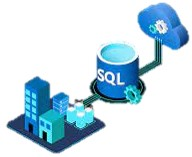

SQL allows local users to access large remote datasets

However, SQL has a built in language that allows you to directly interface with the data, rather than using a separate program like you would for GitHub. This language is one of the most common used in “industry” jobs that people get after leaving academia, such as data scientist or data engineer. This tutorial will be a basic introduction to SQL so that individuals who are interested in jobs outside of academia will have some additional experience relevant to these jobs.

## 1.2 What does SQL do?

SQL is primarily used to interface with very large databases. Unlike datasets in academic settings, many of the databases that companies work with are terabytes worth of data, and cannot simply be stored in a program like Excel or SPSS. SQL allows you to call certain pieces of the database that you are interested in without having to rake through tons of data. You can also use SQL to add or delete data from these databases.

Beyond this, SQL can also be automatized by triggers. Companies can write scripts to automatically append data as it comes in, so that it does not need to be monitored and done by hand. This reduces the need to enter data, and effort can be geared towards data cleaning and other functions.

## 1.3 Why is SQL important?

This isn’t a programming language one would readily encounter in academia. Our datasets are not often big enough to justify using SQL. However, as we see in the image below, SQL is a big part of many data and tech jobs that we might pursue after competing our graduate degrees. It’s pretty unlikely that you would be exposed to this programming language without occupying one of these positions or seeking it out yourself, so we hope this workshop exposes you to some of the basic functions and utility of SQL. It is not a difficult language to learn, so this workshop will provide a foundation for attendees to easily apply for something like an industry job interview.

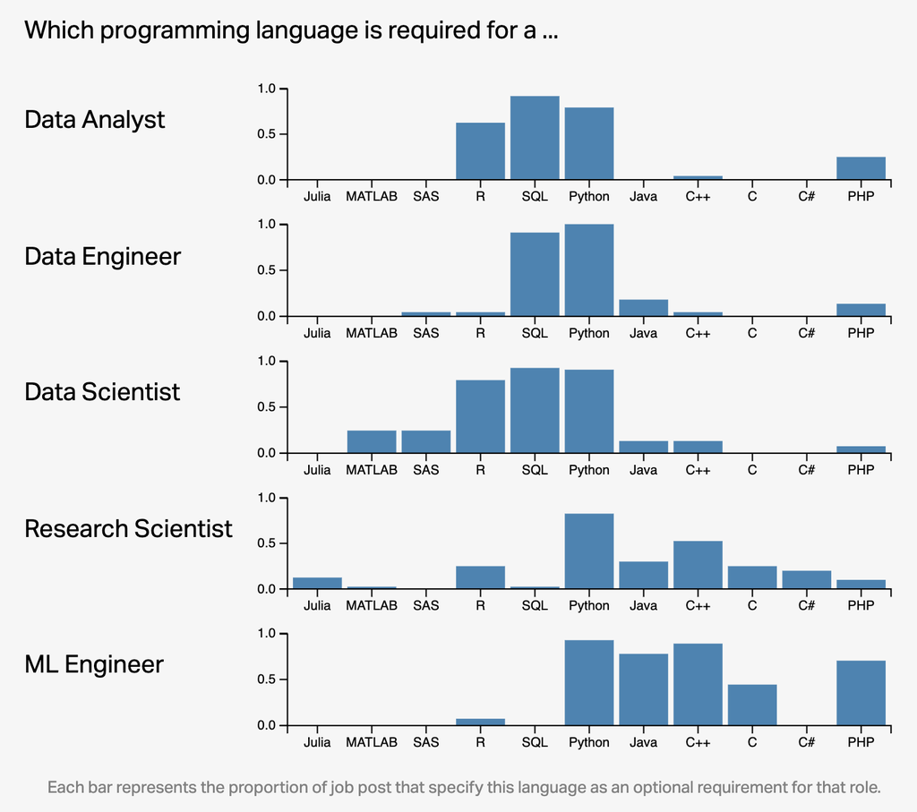

## 1.4 What is a SQL Server?

An SQL Server, also known as a relational database management system (RDBMS), is where the data that SQL accesses is stored. The data stored on these servers are often structured into tables similar to a spreadsheet. These SQL Servers tables can be *massive* and the SQL language offers a relatively quick means of retrieve, insert, update, and delete data in the database, but this is just one of the many reasons why SQL servers are used. SQL servers are designed to handle variably concurrent access requests from different users in an efficient **and** secure manner. A server administrator enforces rules as to who can modify and access what on the server. SQL Servers also feature different options for data backup and recovery and can allow users to perform calculations directly in the table without having to necessarily create a subset of data.

# 2 Setting Up a SQL Server

## 2.1 How to Use SQL with SQL Server

There are multiple ways to use SQL. While we will not be covering how to extensively use SQL Server is this workshop, in favor of languages you all might be familiar with, this seems to be one of the most common ways people use SQL. SQL Server is basically just a program specifically for SQL programming. It is also more secure than something like RSudio and Jupyter Notebooks, so if you are in a job where the data needs to be secure, you are more likely to encounter SQL Server. There are several steps to get **MS SQL** setup on your local computer.

1. Download and install the ODBC Driver, to be able to initialize other code: https://learn.microsoft.com/en-us/sql/connect/odbc/download-odbc-driver-for-sql-server?view=sql-server-ver16 - **make sure you download the correct version of this, either 32- or 64-bit, for your computer.** The 64-bit version has (x64) after it’s name and the 32-bit version has (x86) after it’s name (which we know is kind of confusing!).
2. Download an SQL Server to use; this is the one I use, but there are many of them: https://www.microsoft.com/en-us/sql-server/sql-server-downloads - **scroll down and click ‘Download now’ under ‘Express’**
3. Open SQL Server to configure your connection (choose the basic option and follow the subsequent in-program instructions) - once you have configured, click **Connect Now** to get the server name and location on your computer.

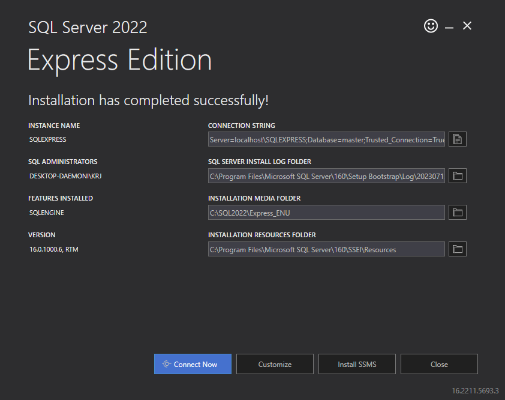

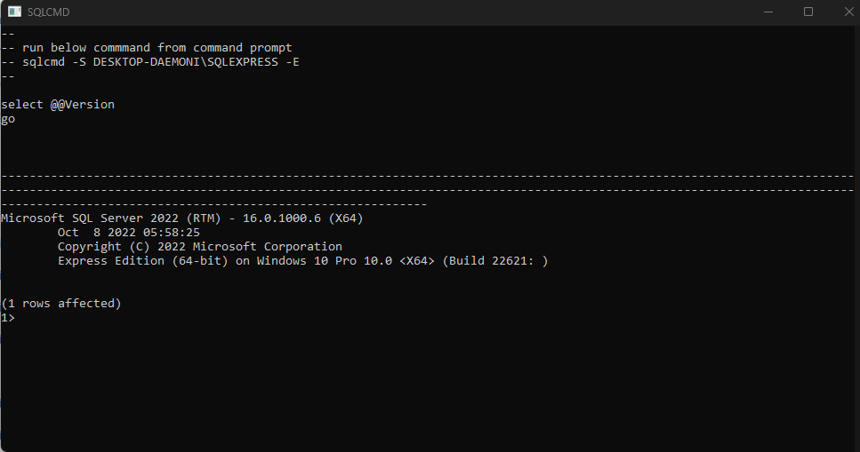

4. Open the ODBC Data Source program that you installed during Step 1. In some cases you may have both so make sure you are opening the correct version of this, either 32- or 64-bit, for your computer. Under the ‘System DSN’ tab, click the ‘Add…’ button.

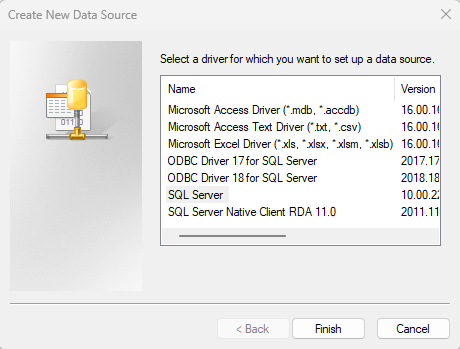

Highlight ‘SQL Server’, and then click ‘Finish’.A new window will pop up. Under Name, name this something you will remember for later. And under Server, enter your server name and location from the command line window.

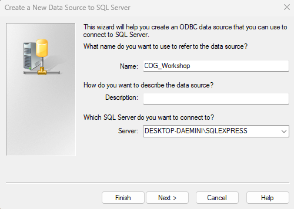

After this, you can click ‘Finish’, then select “Test data Source …”. It will ensure that your connection is established and will print a message stating so if it is. If your connection has been established, click “OK”.

## 2.2 How to Use SQL Server in R

Now, let’s use our newly downloaded MS SQL server to set up in R!

Run the chunk of code below to load packages in R that can deal with SQL data and code:

```r
install.packages(c("pacman"))
library(pacman)
pacman::p_load(DBI, odbc, reader)
```

```r
con_r <- DBI::dbConnect(
  odbc::odbc(),
  "Katie_SQL" #make sure to insert the name you just input your server name here
  )
```

Connect to the MS SQL server, include a code chunk that has this information on your RMarkdown file:

`{sql, connection=con_r}`

## 2.3 How to use SQL in Jupyter Notebooks

Next, let’s do the same for those who may want to set up in Jupyter Notebooks. While this is possible, we will not be covering how to use Jupyter Notebooks extensively. This should give you an idea of how to setup, and you can try this on your own later!

I am running this in RMarkdown so I have to initialize a Python kernel - skip this if you are directly using Jupyter Notebooks!

```r
install.packages("reticulate") #this is for using Python in R - very useful and neat!
library(reticulate)
py_install("pandas")
py_install("pyodbc")
```

Now we have to set the connection in Python with the pyodbc library; there are a few more steps to using SQL in Python code than in R, including setting up a cursor to call the SQL code

```python
import pyodbc
con_py = pyodbc.connect('DRIVER={SQL Server};SERVER=DESKTOP-DAEMONI\SQLEXPRESS01;Trusted_Connection=yes;') #Please note that this is slightly different from how we initialized the connection in R!
cursor = con_py.cursor()

#for any line of code, you have to filter it through this cursor function, e.g.:
#cursor.execute("ALTER TABLE associates
#               "ADD fullName VARCHAR(20)")

#you can also put the SQL code into a variable and execute it using that variable
#sql_insert = ('''
  #"INSERT INTO TABLE VALUES(1, 2, 'apple');''')
)
```

## 2.4 SQL Database example data

Yay! We are all set up to wrangle data in either RStudio or Python.

Loading in data from something like a CSV can be difficult, so we are going to skip that and create our own database using SQL code. Note that SQL syntax is slightly different between the different servers (i.e. MySQL and MS SQL). We are coding in MS SQL, so some of this code may not work if you were to use something like MySQL.

In addition, I find using SQL in R a lot easier, so we are going to stick with that. However, if you want to use Jupyter Notebooks, feel free to follow along and try to run this code within the cursor.execute() function!

First, we add a new database and select it to be used for our code:

```sql
CREATE DATABASE COG_SQL;
```

```sql
USE COG_SQL;
```

Here, we need to create empty tables to insert data into (think of how you would need to create a dataframe in R to put data into!):

```sql
CREATE TABLE  AGENTS (
  AGENT_CODE CHAR(6) NOT NULL PRIMARY KEY,
    AGENT_NAME CHAR(40) NOT NULL,
    WORKING_AREA CHAR(35) NOT NULL,
    COMMISSION INT NOT NULL,
    PHONE_NO CHAR(15) NOT NULL,
    COUNTRY VARCHAR(25) NOT NULL,
     );
```

```sql
CREATE TABLE  CUSTOMER (
  CUST_CODE VARCHAR(6) NOT NULL PRIMARY KEY,
    CUST_NAME VARCHAR(40) NOT NULL,
    CUST_CITY CHAR(35),
    WORKING_AREA VARCHAR(35) NOT NULL,
    CUST_COUNTRY VARCHAR(20) NOT NULL,
    GRADE INT,
    OPENING_AMT INT NOT NULL,
    RECEIVE_AMT INT NOT NULL,
    PAYMENT_AMT INT NOT NULL,
    OUTSTANDING_AMT INT NOT NULL,
    PHONE_NO VARCHAR(17) NOT NULL,
    AGENT_CODE CHAR(6) NOT NULL REFERENCES AGENTS
);
```

```sql
CREATE TABLE  ORDERS
   (
  ORD_NUM INT NOT NULL PRIMARY KEY,
    ORD_AMOUNT INT NOT NULL,
    ADVANCE_AMOUNT INT NOT NULL,
    ORD_DATE DATE NOT NULL,
    CUST_CODE VARCHAR(6) NOT NULL REFERENCES CUSTOMER,
    AGENT_CODE CHAR(6) NOT NULL REFERENCES AGENTS,
    ORD_DESCRIPTION VARCHAR(60) NOT NULL
   );
```

Now, we can insert our fake data into the tables:

```sql
INSERT INTO AGENTS VALUES ('A007', 'Ramasundar', 'Bangalore', 0.15, '077-25814763', '');
INSERT INTO AGENTS VALUES ('A003', 'Alex ', 'London', 0.13, '075-12458969', '');
INSERT INTO AGENTS VALUES ('A008', 'Alford', 'New York', 0.12, '044-25874365', '');
INSERT INTO AGENTS VALUES ('A011', 'Ravi Kumar', 'Bangalore', 0.15, '077-45625874', '');
INSERT INTO AGENTS VALUES ('A010', 'Santakumar', 'Chennai', 0.14, '007-22388644', '');
INSERT INTO AGENTS VALUES ('A012', 'Lucida', 'San Jose', 0.12, '044-52981425', '');
INSERT INTO AGENTS VALUES ('A005', 'Anderson', 'Brisban', 0.13, '045-21447739', '');
INSERT INTO AGENTS VALUES ('A001', 'Subbarao', 'Bangalore', 0.14, '077-12346674', '');
INSERT INTO AGENTS VALUES ('A002', 'Mukesh', 'Mumbai', 0.11, '029-12358964', '');
INSERT INTO AGENTS VALUES ('A006', 'McDen', 'London', 0.15, '078-22255588', '');
INSERT INTO AGENTS VALUES ('A004', 'Ivan', 'Torento', 0.15, '008-22544166', '');
INSERT INTO AGENTS VALUES ('A009', 'Benjamin', 'Hampshair', 0.11, '008-22536178', '');
```

```sql
INSERT INTO CUSTOMER VALUES ('C00013', 'Holmes', 'London', 'London', 'UK', '2', 6000.00, 5000.00, 7000.00, 4000.00, 'BBBBBBB', 'A003');
INSERT INTO CUSTOMER VALUES ('C00001', 'Micheal', 'New York', 'New York', 'USA', '2', 3000.00, 5000.00, 2000.00, 6000.00, 'CCCCCCC', 'A008');
INSERT INTO CUSTOMER VALUES ('C00020', 'Albert', 'New York', 'New York', 'USA', '3', 5000.00, 7000.00, 6000.00, 6000.00, 'BBBBSBB', 'A008');
INSERT INTO CUSTOMER VALUES ('C00025', 'Ravindran', 'Bangalore', 'Bangalore', 'India', '2', 5000.00, 7000.00, 4000.00, 8000.00, 'AVAVAVA', 'A011');
INSERT INTO CUSTOMER VALUES ('C00024', 'Cook', 'London', 'London', 'UK', '2', 4000.00, 9000.00, 7000.00, 6000.00, 'FSDDSDF', 'A006');
INSERT INTO CUSTOMER VALUES ('C00015', 'Stuart', 'London', 'London', 'UK', '1', 6000.00, 8000.00, 3000.00, 11000.00, 'GFSGERS', 'A003');
INSERT INTO CUSTOMER VALUES ('C00002', 'Bolt', 'New York', 'New York', 'USA', '3', 5000.00, 7000.00, 9000.00, 3000.00, 'DDNRDRH', 'A008');
INSERT INTO CUSTOMER VALUES ('C00018', 'Fleming', 'Brisban', 'Brisban', 'Australia', '2', 7000.00, 7000.00, 9000.00, 5000.00, 'NHBGVFC', 'A005');
INSERT INTO CUSTOMER VALUES ('C00021', 'Jacks', 'Brisban', 'Brisban', 'Australia', '1', 7000.00, 7000.00, 7000.00, 7000.00, 'WERTGDF', 'A005');
INSERT INTO CUSTOMER VALUES ('C00019', 'Yearannaidu', 'Chennai', 'Chennai', 'India', '1', 8000.00, 7000.00, 7000.00, 8000.00, 'ZZZZBFV', 'A010');
INSERT INTO CUSTOMER VALUES ('C00005', 'Sasikant', 'Mumbai', 'Mumbai', 'India', '1', 7000.00, 11000.00, 7000.00, 11000.00, '147-25896312', 'A002');
INSERT INTO CUSTOMER VALUES ('C00007', 'Ramanathan', 'Chennai', 'Chennai', 'India', '1', 7000.00, 11000.00, 9000.00, 9000.00, 'GHRDWSD', 'A010');
INSERT INTO CUSTOMER VALUES ('C00022', 'Avinash', 'Mumbai', 'Mumbai', 'India', '2', 7000.00, 11000.00, 9000.00, 9000.00, '113-12345678','A002');
INSERT INTO CUSTOMER VALUES ('C00004', 'Winston', 'Brisban', 'Brisban', 'Australia', '1', 5000.00, 8000.00, 7000.00, 6000.00, 'AAAAAAA', 'A005');
INSERT INTO CUSTOMER VALUES ('C00023', 'Karl', 'London', 'London', 'UK', '0', 4000.00, 6000.00, 7000.00, 3000.00, 'AAAABAA', 'A006');
INSERT INTO CUSTOMER VALUES ('C00006', 'Shilton', 'Torento', 'Torento', 'Canada', '1', 10000.00, 7000.00, 6000.00, 11000.00, 'DDDDDDD', 'A004');
INSERT INTO CUSTOMER VALUES ('C00010', 'Charles', 'Hampshair', 'Hampshair', 'UK', '3', 6000.00, 4000.00, 5000.00, 5000.00, 'MMMMMMM', 'A009');
INSERT INTO CUSTOMER VALUES ('C00017', 'Srinivas', 'Bangalore', 'Bangalore', 'India', '2', 8000.00, 4000.00, 3000.00, 9000.00, 'AAAAAAB', 'A007');
INSERT INTO CUSTOMER VALUES ('C00012', 'Steven', 'San Jose', 'San Jose', 'USA', '1', 5000.00, 7000.00, 9000.00, 3000.00, 'KRFYGJK', 'A012');
INSERT INTO CUSTOMER VALUES ('C00008', 'Karolina', 'Torento', 'Torento', 'Canada', '1', 7000.00, 7000.00, 9000.00, 5000.00, 'HJKORED', 'A004');
INSERT INTO CUSTOMER VALUES ('C00003', 'Martin', 'Torento', 'Torento', 'Canada', '2', 8000.00, 7000.00, 7000.00, 8000.00, 'MJYURFD', 'A004');
INSERT INTO CUSTOMER VALUES ('C00009', 'Ramesh', 'Mumbai', 'Mumbai', 'India', '3', 8000.00, 7000.00, 3000.00, 12000.00, 'Phone No', 'A002');
INSERT INTO CUSTOMER VALUES ('C00014', 'Rangarappa', 'Bangalore', 'Bangalore', 'India', '2', 8000.00, 11000.00, 7000.00, 12000.00, 'AAAATGF', 'A001');
INSERT INTO CUSTOMER VALUES ('C00016', 'Venkatpati', 'Bangalore', 'Bangalore', 'India', '2', 8000.00, 11000.00, 7000.00, 12000.00, 'JRTVFDD', 'A007');
INSERT INTO CUSTOMER VALUES ('C00011', 'Sundariya', 'Chennai', 'Chennai', 'India', '3', 7000.00, 11000.00, 7000.00, 11000.00, 'PPHGRTS', 'A010');
```

```sql
INSERT INTO ORDERS VALUES(200100, 1000.00, 600.00, '08/01/2008', 'C00013', 'A003', 'SOD');
INSERT INTO ORDERS VALUES(200110, 3000.00, 500.00, '04/15/2008', 'C00019', 'A010', 'SOD');
INSERT INTO ORDERS VALUES(200107, 4500.00, 900.00, '08/30/2008', 'C00007', 'A010', 'SOD');
INSERT INTO ORDERS VALUES(200112, 2000.00, 400.00, '05/30/2008', 'C00016', 'A007', 'SOD');
INSERT INTO ORDERS VALUES(200113, 4000.00, 600.00, '06/10/2008', 'C00022', 'A002', 'SOD');
INSERT INTO ORDERS VALUES(200102, 2000.00, 300.00, '05/25/2008', 'C00012', 'A012', 'SOD');
INSERT INTO ORDERS VALUES(200114, 3500.00, 2000.00, '08/15/2008', 'C00002', 'A008', 'SOD');
INSERT INTO ORDERS VALUES(200122, 2500.00, 400.00, '09/16/2008', 'C00003', 'A004', 'SOD');
INSERT INTO ORDERS VALUES(200118, 500.00, 100.00, '07/20/2008', 'C00023', 'A006', 'SOD');
INSERT INTO ORDERS VALUES(200119, 4000.00, 700.00, '09/16/2008', 'C00007', 'A010', 'SOD');
INSERT INTO ORDERS VALUES(200121, 1500.00, 600.00, '09/23/2008', 'C00008', 'A004', 'SOD');
INSERT INTO ORDERS VALUES(200130, 2500.00, 400.00, '07/30/2008', 'C00025', 'A011', 'SOD');
INSERT INTO ORDERS VALUES(200134, 4200.00, 1800.00, '09/25/2008', 'C00004', 'A005', 'SOD');
INSERT INTO ORDERS VALUES(200108, 4000.00, 600.00, '02/15/2008', 'C00008', 'A004', 'SOD');
INSERT INTO ORDERS VALUES(200103, 1500.00, 700.00, '05/15/2008', 'C00021', 'A005', 'SOD');
INSERT INTO ORDERS VALUES(200105, 2500.00, 500.00, '07/18/2008', 'C00025', 'A011', 'SOD');
INSERT INTO ORDERS VALUES(200109, 3500.00, 800.00, '07/30/2008', 'C00011', 'A010', 'SOD');
INSERT INTO ORDERS VALUES(200101, 3000.00, 1000.00, '07/15/2008', 'C00001', 'A008', 'SOD');
INSERT INTO ORDERS VALUES(200111, 1000.00, 300.00, '07/10/2008', 'C00020', 'A008', 'SOD');
INSERT INTO ORDERS VALUES(200104, 1500.00, 500.00, '03/13/2008', 'C00006', 'A004', 'SOD');
INSERT INTO ORDERS VALUES(200106, 2500.00, 700.00, '04/20/2008', 'C00005', 'A002', 'SOD');
INSERT INTO ORDERS VALUES(200125, 2000.00, 600.00, '10/10/2008', 'C00018', 'A005', 'SOD');
INSERT INTO ORDERS VALUES(200117, 800.00, 200.00, '10/20/2008', 'C00014', 'A001', 'SOD');
INSERT INTO ORDERS VALUES(200123, 500.00, 100.00, '09/16/2008', 'C00022', 'A002', 'SOD');
INSERT INTO ORDERS VALUES(200120, 500.00, 100.00, '07/20/2008', 'C00009', 'A002', 'SOD');
INSERT INTO ORDERS VALUES(200116, 500.00, 100.00, '07/13/2008', 'C00010', 'A009', 'SOD');
INSERT INTO ORDERS VALUES(200124, 500.00, 100.00, '06/20/2008', 'C00017', 'A007', 'SOD');
INSERT INTO ORDERS VALUES(200126, 500.00, 100.00, '06/24/2008', 'C00022', 'A002', 'SOD');
INSERT INTO ORDERS VALUES(200129, 2500.00, 500.00, '07/20/2008', 'C00024', 'A006', 'SOD');
INSERT INTO ORDERS VALUES(200127, 2500.00, 400.00, '07/20/2008', 'C00015', 'A003', 'SOD');
INSERT INTO ORDERS VALUES(200128, 3500.00, 1500.00, '07/20/2008', 'C00009', 'A002', 'SOD');
INSERT INTO ORDERS VALUES(200135, 2000.00, 800.00, '09/16/2008', 'C00007', 'A010', 'SOD');
INSERT INTO ORDERS VALUES(200131, 900.00, 150.00, '08/26/2008', 'C00012', 'A012', 'SOD');
INSERT INTO ORDERS VALUES(200133, 1200.00, 400.00, '06/29/2008', 'C00009', 'A002', 'SOD');
```

Now we have our own database with three tables of data inside! The code chunks should run without error, but if you want to check that this worked within RMarkdown, you can look over to where your ‘Environment’ tab is, and there should now be a ‘Connections’ tab. Click on this, and it should display all of the databases you have within SQL. As new users, you should only have ‘master’, ‘msdb’, ‘tempdb’ and maybe ‘model’. If you click on the dropdown next to our database (COG_SQL), you should be able to see the tables we just added!

[figure not shown]

# 3 Coding in SQL

## 3.1 Syntax and Organization of Code

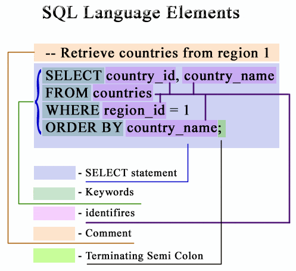

There are a few things about the structure of SQL code that we should touch on before moving on to any code. The functions are generally shown as capitalized (see the above creations of our tables). However, this is not necessary and the functions can be written in lowercase if you would prefer.

Semi-colons are generally used to end commands, as you can also see above. HWhen you have a multi-line command you would like to execute, it can either be broken up into those separate lines (like you can see above, when we were setting up the columns for our tables), but they can also be all on one line if you would like. Comments can be added by including `--` in front of text. However, as we are working in RStudio, `#` also allows you to make comments.

Otherwise, the syntax is very straightforward. You generally have a function you want to perform (like `CREATE`). and object you would like to perform this function on (like `TABLE`), and then a name to call it. There are some more advanced forms of SQL syntax, and we will try and touch on them a little later in the workshop.

## 3.2 Reviewing Previous SQL Commands

As we have already demonstrated some SQL code already, let’s review it. Recall that we created a database, then created empty tables, and then populated those tables with data. This is generally how things work within SQL; it is difficult to import data any other way, such as Excel (trust us, we tried!). When you want to create something, you use the `CREATE` function. When you want to delete something, you use the `DROP` function. A database has to come before a table, and tables are simply where the data is stored in the database.

We used the `CREATE` function to create our database `COG_SQL`. We also had to choose our database to work with before being able to access it. This is to prevent users from accidentally editing a database that they did not intend to. We executed the `USE` command to do this.

Finally, initialized all of our tables with their column names and entered in that data. You can think of using `CREATE TABLE` like you would create a DataFrame in R. Then, we used `INSERT INTO` to add our data to a specific table. The data on each line represents a new row, and needs to match up to the number of columns and the type of data in those columns. The `VALUES` command tells SQL that this is data that we are loading into the table.

If we wanted to view our tables, we can use the `SELECT` function:

```sql
SELECT *
From AGENTS;
```

## 3.3 Data Types

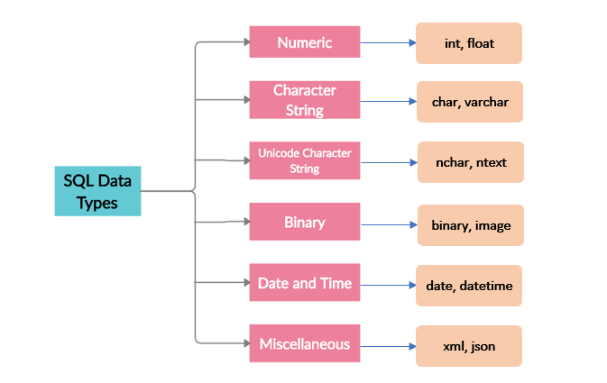

As you can see from our database creation, there are different data types in SQL. In addition to the data type, you can also specify the longest number of characters that will be present within a variable (i.e. `VARCHAR(20)` means that the character string will only have 20 characters at max). These are slightly different between SQL servers, so beware! In addition, the way data types are handled when they are being fed into a table is different, as well; for instance, an `INT` is not surrounded by single quote marks like other `CHAR` or `NCHAR` variables.

It is important to note that data types are important when it comes to SQL. The data needs to be in the correct format as designated by the variable type we assigned it when creating the table (i.e., `AGENT_CODE` was assigned as `CHAR`). Otherwise, you will encounter a lot of errors trying to load in your data.

One final point we would like to make is about the `PRIMARY KEY` functions that were showcased in these tables. This function allows you to uniquely identify data across multiple tables. For instance, something like this could be helpful if you had patient data and experimental data for that patient; you would want to keep all of their demographics data together in one place, and their experimental data in another, with their Subject ID being the `PRIMARY KEY` between those two tables. You do have to make sure you tell the table which variable is being referenced from the original table (you can see that in the `CUSTOMER`, where `AGENT_CODE` is referenced from `AGENTS`).

Now that we have walked through what has already been done, let’s explore some more functions in SQL!

## 3.4 Key Functions

Functions in SQL are very easy. We have actually provided you all with a cheat sheet for the functions that can be found in SQL. This is because once you see an example of SQL code, it’s difficult to do it differently in a way that may help you learn it. However, we think that by supplying this cheat sheet for you, it will mimic real-life SQL coding in a way that will make you more comfortable a) figuring out which functions to use on your own and b) navigating a cheat sheet, which I would highly recommend using in the future if you are trying to use SQL.

If you have not already downloaded the cheat sheet we have provided, you can find it in the COG Summer Workshop GitHub: ‘cog_summer_workshop_2023/sql/Cheat Sheet/SQL Cheat Sheet PDF by Kanak Infosystems LLP.pdf’

### 3.4.1 Exercise 1: How to call only certain data from our tables

For this exercise, we want you to use your cheat sheet to figure out how to only display the customer codes for our ORDERS table. We will give you the general syntax outline, but put your guess at which functions we would use in the chat!

```r
___ CUST_CODE
___ ORDERS
```

Click `SHOW` to see the solution! ==>

```sql
SELECT CUST_CODE
FROM ORDERS
```

### 3.4.2 Exercise 2: Filter data by a criteria

For this exercise, try and write some SQL code that takes data from the `ORDERS` table but only includes orders over $1000 (from the `ORD_AMOUNT` variable).

```r
____ *
____ ORDERS
____ ORD_AMOUNT > ____;
```

Click `SHOW` to see the solution! ==>

```sql
SELECT *
FROM ORDERS
WHERE ORD_AMOUNT > 1000;
```

Note that an example of how to use a wildcard in this situation is included above; when you want to select all columns from a table, the wildcard operator is the way to go!

### 3.4.3 Exercise 3: Selecting unique items from a column

Sometimes we want to find all of the unique items in a list without all of the duplicates. Trying doing that here for the `CUSTOMER` table!

Click `SHOW` to see the solution! ==>

```sql
SELECT DISTINCT CUST_CITY
FROM CUSTOMER;
```

### 3.4.4 Exercise 4: How to change data in an already existing table

For this exercise, we want to modify data that already exists within a table we have created. We are skipping how to create a table, because we saw how to create and populate one above. However, sometimes you need to change the information of the data that is in the table.

For this example, we would like you to try and rename the WORKING_AREA variable in the AGENTS table to CITY.

Click `SHOW` to see the solution! ==>

```sql
ALTER TABLE AGENTS
RENAME COLUMN WORKING_AREA to CITY;
```

### 3.4.5 Exercise 5: Adding data to a column

Now, we have seen this done before, but this is your opportunity to try and apply what you have already seen in this workshop. The `COUNTRY` variable in the `AGENTS` table is blank. Figure out what country should go into each row for this dataset and add them in (hint: you will need to reference another variable to tell SQL which row to enter the data in).

Click `SHOW` to see the solution! ==>

```sql
UPDATE AGENTS
SET COUNTRY = 'India'
WHERE AGENT_CODE = 'A001';

UPDATE AGENTS
SET COUNTRY = 'India'
WHERE AGENT_CODE = 'A002';

UPDATE AGENTS
SET COUNTRY = 'UK'
WHERE AGENT_CODE = 'A003';

UPDATE AGENTS
SET COUNTRY = 'Canida'
WHERE AGENT_CODE = 'A004';

UPDATE AGENTS
SET COUNTRY = 'Australia'
WHERE AGENT_CODE = 'A005';

UPDATE AGENTS
SET COUNTRY = 'UK'
WHERE AGENT_CODE = 'A006';

UPDATE AGENTS
SET COUNTRY = 'India'
WHERE AGENT_CODE = 'A007';

UPDATE AGENTS
SET COUNTRY = 'USA'
WHERE AGENT_CODE = 'A008';

UPDATE AGENTS
SET COUNTRY = 'UK'
WHERE AGENT_CODE = 'A009';

UPDATE AGENTS
SET COUNTRY = 'India'
WHERE AGENT_CODE = 'A010';

UPDATE AGENTS
SET COUNTRY = 'India'
WHERE AGENT_CODE = 'A011';

UPDATE AGENTS
SET COUNTRY = 'USA'
WHERE AGENT_CODE = 'A012';
```

### 3.4.6 Exercise 6: Adding two tables together

Remember when we mentioned how our tables are linked by `PRIMARY KEYS`? Well, let’s use those primary keys to add two tables together! Add the `AGENTS` and `ORDERS` tables together below. Make sure that all of the records from `ORDERS` are added to the `AGENTS` table!

(hint: there is a function like this in R, where you will have to choose between a few different options to add these tables together correctly!)

Click `SHOW` to see the solution! ==>

```sql
SELECT *
FROM AGENTS
LEFT JOIN ORDERS
ON AGENTS.AGENT_CODE = ORDERS.AGENT_CODE
```

### 3.4.7 Exercise 7: Removing columns

Once you load in a table, it can actually be annoying to modify it if there are multiple mistakes. There is a function which allows you to get rid of a table completely from your database so you can start anew. You can also get rid of specific columns.

For this exercise, try getting rid of the `COUNTRY` column in the `AGENTS` table! We will avoid getting rid of the whole table in case you use the `AGENTS` table in the next exercises.

Click `SHOW` to see the solution! ==>

```sql
ALTER TABLE AGENTS
DROP COLUMN COUNTRY;
```

# 4 Integration & Analyses

## 4.1 Using SQL in R

Once we have our data in R, we might want to do some analyses with it. Here is how you import the data into R to be used:

```r
agents <- DBI::dbReadTable(con_r, "AGENTS")
cust <- DBI::dbReadTable(con_r, "CUSTOMER")
orders <- DBI::dbReadTable(con_r, "ORDERS")
```

It is easier to import the entire table in this case. Now we have our tables inside R, we can run whatever stats/visualizations that we need! You can also view the data in the ‘Environment’ tab in RStudio, which is much better than having to `SELECT` the data repeatedly!

Here is a boxplot of opening payment amount by country:

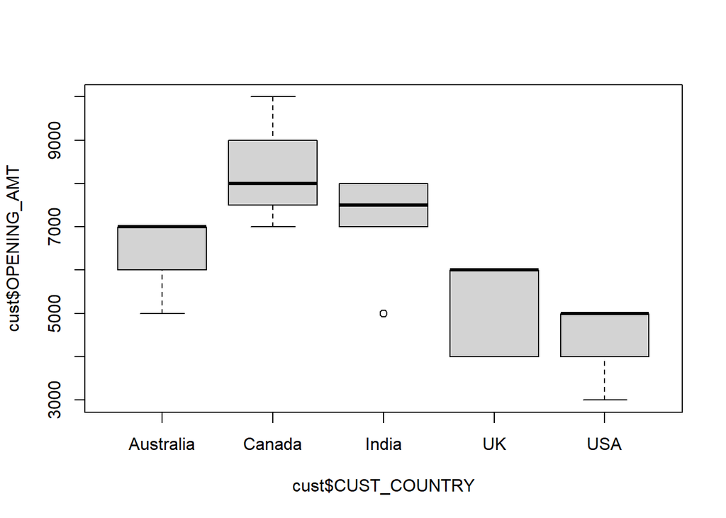

```r
boxplot(cust$OPENING_AMT ~ cust$CUST_COUNTRY, data = cust)
```

And here is a one-way ANOVA with that same data:

```r
oneway.test(cust$OPENING_AMT ~ cust$CUST_COUNTRY, data = cust, var = FALSE)
```

```
##
##  One-way analysis of means (not assuming equal variances)
##
## data:  cust$OPENING_AMT and cust$CUST_COUNTRY
## F = 6.4941, num df = 4.0000, denom df = 6.2774, p-value = 0.02073
```

You could see how this would be helpful when dealing with very large datasets.

### 4.1.1 Exercise 8: Try your own analysis in R!

Using the data we have here in our three tables, try out one more analysis all on your own. Maybe… a regression??

# 5 Advanced Functions

Now, going through this workshop, you are probably thinking to yourself, “This is *too* easy.” And that’s because… it kind of is. SQL is generally an easy language to learn and execute. If you were to use SQL at a job for something like Data Science, a lot of the hard parts of the workshop today would already be set up for you (such as the server you would use, the database you would be working in, and what type of program you would use to execute SQL commands). However, we are going to touch briefly on one advanced function that might make working in a large database a little easier.

As we are not providing a more in-depth look at functions that would help you with a more intense data job, you can utilize a few resources below if you want to dive deeper into SQL:

[FreeCodeCamp](https://www.freecodecamp.org/news/advanced-sql-techniques/)

[Kaggle](https://www.kaggle.com/learn/advanced-sql)

## 5.1 Stored Procedures

A stored procedure is basically like a function in R. You often have to do the same thing in SQL over and over again (like viewing certain types of data). This is a good opportunity to take advantage of stored procedures to do the heavy lifting for you!

The general syntax looks like this:

```sql
CREATE PROCEDURE procedure_name
AS
sql_statment
GO;
```

```sql
EXEC procedure_name;
```

You can also pass variables into this function. If you want to be able to include a variable in your stored procedure, you can use something like `@ADVANCE_AMOUNT` to give a placeholder to where that variable would go. For instance:

```sql
CREATE PROCEDURE CitySelect @City nvarchar(25)
AS
SELECT * FROM CUSTOMER WHERE CUST_CITY = @City;
```

```sql
EXEC CitySelect @City = 'LONDON';
```

### 5.1.1 Exercise 9: Create your own stored procedure!

For this exercise, we want you to create a store procedure where `CUST_COUNTRY` is USA and the `RECEIVE_AMT` is less than 8000!

(hint: this would be a good time to take advantage of SQL operators!)

Click `SHOW` to see the solution! ==>

```sql
CREATE PROCEDURE Country_Amount @City nvarchar(25), @Amount int
AS
SELECT * FROM CUSTOMER WHERE CUST_COUNTRY = @City AND RECEIVE_AMT < @Amount;
```

```sql
EXEC Country_Amount @City = 'USA', @Amount = 8000
```

# 6 Conclusion

[video not shown]

That concludes our workshop on SQL! Hopefully we have provided you with the building blocks to be successful in using SQL in your future industry jobs.